# Variance Estimation for Multiply Imputed Response Variables Under Uncongeniality: A Monte Carlo Simulation Study

Ihsan E. Buker & Samantha R. Seals

2022-08-11

# Background

Missing data is an issue ubiquitous in many fields of science. Given that statistical procedures often require data to be fully observed, there has long been an interest and need to manage missing data in a way that allows researchers to reach valid conclusions. Today, multiple imputation is accepted as the gold standard in missing data analysis, in no short thanks to the work of Donald Rubin (Buuren 2012). In 1977, Rubin proposed using multiple completed versions of the dataset with missing observations, applying the complete-data procedure of interest, and pooling the estimates to draw valid inferences (Buuren 2012). The main advantage of multiple imputation, as opposed to single imputation, which had been used by researchers since the early 1970s, is its ability to properly estimate the variance caused by missing observations (Efron 1994). The emphasis placed on variance and uncertainty by Rubin was a departure from the status quo of the time, which was to fill in the missing observation with the most probable value and to proceed with complete case analyses as if the observation had not been missing, to begin with (Buuren 2012). This approach, however, fails to incorporate the loss of information caused by missing observations into the estimation of parameters, resulting in the underestimation of variance (Rubin 1978).

Like all revolutionary ideas, multiple imputation received harsh criticism following its conception. Perhaps the most notable of the objections came from Fay in 1992, who demonstrated through counterexamples that multiple imputation produced biased covariance estimates (Bartlett and Hughes 2020). Fay added the need for unison between the imputation and analysis model made multiple imputation a poor general-purpose tool, particularly in instances where the imputer and analyst are different individuals (Fay 1992; Buuren 2012). Fay’s arguments led to the conceptualization of congeniality between the imputation and analysis model, which was later accepted to be a requirement to obtain valid inferences from multiple imputation using Rubin’s pooling rules (Buuren 2012; Meng 1994). Although Fay’s work initially criticized biases introduced to the covariance matrix following multiple imputation, a similar phenomenon of biased estimations were observed with variance under uncongeniality (Fay 1992; Meng 1994; Xie and Meng 2016).

Some of the earliest works demonstrating Rubin’s variance estimator to be biased under uncongeniality were from Wang (1998) and Robins, who also proposed an alternate variance estimator in the same paper (Buuren 2012). The variance estimator proposed by Wang and Robins requires the calculation of several quantities, which are not easily accessible to the average statistical practitioner (Bartlett and Hughes 2020). The challenging construction of the variance estimator proposed by Wang and Robins has resulted in it receiving little-to-no attention in applied settings (Bartlett and Hughes 2020). In an attempt to create a more user-friendly variance estimator in instances of suspected uncongeniality, researchers have proposed combining resampling methods with multiple imputation. Of the two main resampling methods, bootstrap has received more attention from multiple imputation researchers compared to jackknife resampling, which has mostly been investigated under single hot-deck imputation. Although particular combinations of bootstrap and multiple imputation have been demonstrated to create asymptotically unbiased estimates of variance, the associated computational cost makes this an active area of research (Bartlett and Hughes 2020). Most recently, von Hippel has proposed a bootstrap variance estimator which addresses the issue of computational cost; however, it has been demonstrated to create confidence intervals that are slightly wider compared to traditional bootstrap and multiple imputation combinations (Bartlett and Hughes 2020). Given the lower computational cost associated with jackknife resampling, as well as desirable properties demonstrated under single imputation, such as being unbiased in certain scenarios, it is an attractive alternative that should be considered as a variance estimator of multiply imputed data under uncongeniality (Chen and Shao 2001; Rao and Shao 1992).

# Research Goals

## Long-Term

The long-term goal of this research project is to develop a jackknife variance estimator that can provide asymptotically unbiased estimates under uncongeniality at a reasonable computational cost, namely, one that can easily be attained in applied settings. The long-term goals of this research project may be particularized by the following set of questions presented.

- What are the properties of the jackknife variance estimator in multiply imputed datasets, namely, datasets containing missing outcome variables imputed through predictive mean matching?
- In what manner should the jackknife estimator be combined with multiple imputation to obtain an estimator with desirable characteristics?
- How do the characteristics of the response variable, such as the proportion of missingness, and the number of observations influence the performance of the proposed jackknife variance estimator?
- How does the proposed jackknife variance estimator compare to Rubin’s rules, and bootstrap resampling methods in estimating the variance of multiply imputed variables under uncongeniality?
- If any bias is noted in the variance estimates obtained through the jackknife estimator, are they negligible given the decreased computational cost?

## Short-Term

The short-term goal of this research project was to examine various characteristics of robust variance estimation methods in the literature, such as the bias of the point estimator, confidence interval width, coverage probability, and computational cost. The methods examined draw from Bayesian and frequentist frameworks to construct various estimators using bootstrap resampling combined with multiple imputation. The short-term goals of this project may be particularized by the following set of questions presented.

- How does the quality of the point estimator obtained by different methods vary under differing sample sizes, percentage of missing data, and congeniality?
- How do the characteristics of the confidence interval obtained by different methods vary under differing sample sizes, percentage of missing data, and congeniality?
- How does the computational expense of the different methods compare to one another, and can they realistically be performed in applied settings?

# Research Methods

Each of the $N$ datasets generated with the foregoing characteristics will be imputed using the $\texttt{mice()}$ function. In order to determine $m$, which represents the number of complete datasets to be generated per $N$, von Hippel’s two-stage $m$ calculator will be utilized (Hippel 2020). The imputation process will be visually monitored for convergence using a pilot study with small $N$, which will help determine the maximum number of iterations each combination of $N$ and $m$ are allowed to go through. Finally, the imputation method for the outcome variable will be predictive mean matching.

The analysis model of interest is as follows,

$$Y \sim V_1 + V_2 + V_3 + V_2:V_3+\epsilon$$
where the congenial imputation model is

$$Y_{\text{mis}} \sim V_1 + V_2 + V_3 + V_2:V_3$$
and the uncongenial imputation model is

$$Y_{\text{mis}} \sim V_1 + V_2 + V_3$$

Initially, the imputation model utilized by $\texttt{mice()}$ will be uncongenial to the analysis model, per the definition of congeniality set forth in the appendix. Thereafter, the analysis model of interest to estimate $\theta = \text{var}(V_2)$ will be applied to each of the $m$ datasets, and $\text{var}(\hat{\theta})$ will be estimated using the jackknife estimator. The foregoing process will be repeated under a congenial imputation and analysis model pairing, which will serve as the control. All analyses will be conducted using $\texttt{R}$ 4.2.1 (Funny-Looking Kid), alongside $\texttt{mice}$ 3.14.0, $\texttt{rsample}$ 1.0.0, $\texttt{bootImpute}$ 1.2.0, and $\texttt{tidyverse}$ 1.3.1.

# Results

Please see the following [link](https://mi-var-est.shinyapps.io/mi_var_est/) for an interactive presentation of the results accompanied by visuals, and Data for the complete set of results only.

## General observations

With that being said, the following trends observed in the simulation are worthwhile for further study and discussion. Increases in sample size were met with narrower confidence intervals, which is not surprising, given the inverse square root relationship between margin of error and sample size. Somewhat paradoxically, however, increased sample size led to higher coverage probability, although the confidence intervals got narrower, which is likely due to improvements in the point estimation. Moreover, it was noted that at higher percentages of missing data, Rubin’s rules began producing less accurate point estimates with narrower confidence intervals compared to bootstrap-based methods, which, rightly so, began producing wider confidence intervals as the percentage of missing data increased. Interestingly, the performance of the point estimates in bootstrap-based methods did not vary significantly as the percentage of missing data increased; however, was worse than the estimates provided by Rubin’s rules under congeniality and low percentages of missing data. Finally, across most conditions, it was noted that the bootstrap MI pooled method had the highest coverage probability under uncongeniality; however, also had the least accurate point estimates, which improved as the sample size increased.

# Discussion

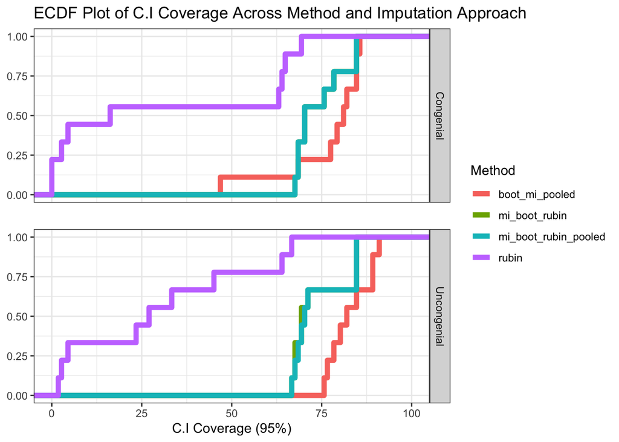

ECDF, which stands for empirical cumulative distribution function, is a step-wise function associated with the distribution of the sample. The y-axis of this plot, which represents the cumulative probability, corresponds to the fraction of observations of the measured variable that are less than or equal to the corresponding value on the x-axis.

As the number of samples tends to infinity, the 95% confidence interval generated from each of the samples should contain the true parameter in 95% of the instances. This property of confidence intervals, however, holds only when the population is normally distributed or when the sample sizes are large enough that the central limit theorem grants convergence to the normal distribution. However, normality or large samples are not always found in practice. As such, simulation studies, such as the one conducted here, can be used to estimate coverage probability under different circumstances. Ideally, the coverage probability should equal the confidence level, which, in this graph, would be indicated by a line $y \approx 0$ up until $x \approx 95$, a sharp peak at $x = 95$, and $y = 1$ thereafter, until $x = 100$.

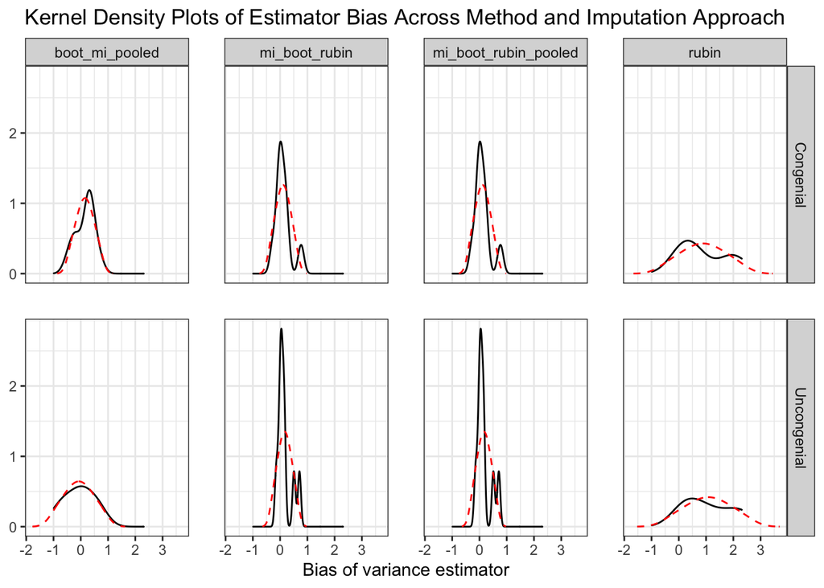

Kernel density plots are based on probability density estimation, which is a non-parametric method used to estimate the probability density function of a variable. The y-axis of this plot, which represents the probability density, corresponds roughly to the likelihood of observing the corresponding value on the x-axis. The qualifier “roughly” is used here, as the probability of a continuous outcome being observed can only be calculated over a range in the following manner.

Say, we want to estimate the probability of the estimator $\hat \theta$ being unbiased (i.e., $\lvert\theta - \hat \theta\rvert = 0$). Let $X$ be the bias of the estimator $\hat \theta$. We would need to select two $X$ values such that the desired outcome $X = C$ where $C \in \text{dom}(f)$ is flanked. Let the greater of such values be $a = X + \epsilon$, and the lesser be $b = X - \epsilon$. Thereafter, $\int^a_b{f(x) \ dx} = P[X \in (a,b)]$ where $f(x)$ is the probability density function of $X$.

# References

Bartlett, Jonathan W, and Rachael A Hughes. 2020. “Bootstrap Inference for Multiple Imputation Under Uncongeniality and Misspecification.” *Statistical Methods in Medical Research* 29 (12): 3533–46. https://doi.org/10.1177/0962280220932189.

Buuren, Stef van. 2012. *Flexible Imputation of Missing Data*. Chapman & Hall/CRC Interdisciplinary Statistics Series. Boca Raton, FL: CRC Press.

Chen, Jiahua, and Jun Shao. 2001. “Jackknife Variance Estimation for Nearest-Neighbor Imputation.” *Journal of the American Statistical Association* 96 (453): 260–69. https://doi.org/10.1198/016214501750332839.

Efron, Bradley. 1994. “Missing Data, Imputation, and the Bootstrap.” *Journal of the American Statistical Association* 89 (426): 463–75. https://doi.org/10.1080/01621459.1994.10476768.

Fay, Robert E. 1992. “When Are Inferences from Multiple Imputation Valid?.”

Hippel, Paul T. von. 2020. “How Many Imputations Do You Need? A Two-Stage Calculation Using a Quadratic Rule.” *Sociological Methods & Research* 49 (3): 699–718. https://doi.org/10.1177/0049124117747303.

Meng, Xiao-Li. 1994. “Multiple-Imputation Inferences with Uncongenial Sources of Input.” *Statistical Science* 9 (4): 538–58. https://doi.org/10.1214/ss/1177010269.

Rao, J. N. K., and J. Shao. 1992. “Jackknife Variance Estimation with Survey Data Under Hot Deck Imputation.” *Biometrika* 79 (4): 811–22. https://doi.org/10.2307/2337236.

Rubin, Donald B. 1978. “Multiple Imputations in Sample Surveys-a Phenomenological Bayesian Approach to Nonresponse.” In *Proceedings of the Survey Research Methods Section of the American Statistical Association*, 1:20–34. American Statistical Association Alexandria, VA, USA.

Wang, N. 1998. “Large-Sample Theory for Parametric Multiple Imputation Procedures.” *Biometrika* 85 (4): 935–48. https://doi.org/10.1093/biomet/85.4.935.

Xie, Xianchao, and Xiao-Li Meng. 2016. “Dissecting Multiple Imputation from a Multi-Phase Inference Perspective: What Happens When God’s, Imputer’s and Analyst’s Models Are Uncongenial?” *Statistica Sinica*. https://doi.org/10.5705/ss.2014.067.

# Appendix

## Data

| Method | Imputation Approach | Median C.I width | Median estimated variance | Estimated variance (complete) | C.I Coverage (95%) | Sample Size | Percentage of Missing Data |
| --- | --- | --- | --- | --- | --- | --- | --- |
| boot_mi_pooled | Congenial | 5.84 | 9.82 | 9.52 | 81.98 | 500 | 0.1 |
| boot_mi_pooled | Congenial | 5.86 | 10.17 | 9.52 | 81.08 | 500 | 0.3 |
| boot_mi_pooled | Congenial | 5.95 | 9.80 | 9.52 | 85.59 | 500 | 0.5 |
| boot_mi_pooled | Congenial | 2.01 | 6.65 | 6.32 | 79.28 | 1000 | 0.1 |
| boot_mi_pooled | Congenial | 2.08 | 6.64 | 6.32 | 77.48 | 1000 | 0.3 |
| boot_mi_pooled | Congenial | 2.03 | 6.63 | 6.32 | 68.47 | 1000 | 0.5 |
| boot_mi_pooled | Congenial | 0.55 | 7.28 | 7.48 | 84.68 | 10000 | 0.1 |
| boot_mi_pooled | Congenial | 0.53 | 7.33 | 7.48 | 84.68 | 10000 | 0.3 |
| boot_mi_pooled | Congenial | 0.66 | 7.04 | 7.48 | 46.85 | 10000 | 0.5 |
| boot_mi_pooled | Uncongenial | 3.41 | 8.53 | 9.52 | 84.68 | 500 | 0.1 |
| boot_mi_pooled | Uncongenial | 4.02 | 8.93 | 9.52 | 76.58 | 500 | 0.3 |
| boot_mi_pooled | Uncongenial | 3.97 | 8.97 | 9.52 | 80.18 | 500 | 0.5 |
| boot_mi_pooled | Uncongenial | 1.72 | 6.68 | 6.32 | 81.98 | 1000 | 0.1 |
| boot_mi_pooled | Uncongenial | 1.63 | 6.81 | 6.32 | 75.68 | 1000 | 0.3 |
| boot_mi_pooled | Uncongenial | 2.86 | 7.11 | 6.32 | 78.38 | 1000 | 0.5 |
| boot_mi_pooled | Uncongenial | 0.89 | 7.45 | 7.48 | 89.19 | 10000 | 0.1 |
| boot_mi_pooled | Uncongenial | 0.76 | 7.53 | 7.48 | 90.99 | 10000 | 0.3 |
| boot_mi_pooled | Uncongenial | 0.72 | 7.32 | 7.48 | 89.19 | 10000 | 0.5 |
| mi_boot_rubin | Congenial | 3.88 | 9.55 | 9.52 | 68.47 | 500 | 0.1 |
| mi_boot_rubin | Congenial | 3.90 | 10.29 | 9.52 | 68.47 | 500 | 0.3 |
| mi_boot_rubin | Congenial | 4.18 | 9.77 | 9.52 | 70.27 | 500 | 0.5 |
| mi_boot_rubin | Congenial | 1.77 | 6.26 | 6.32 | 78.38 | 1000 | 0.1 |
| mi_boot_rubin | Congenial | 1.82 | 6.44 | 6.32 | 70.27 | 1000 | 0.3 |
| mi_boot_rubin | Congenial | 2.10 | 6.52 | 6.32 | 67.57 | 1000 | 0.5 |
| mi_boot_rubin | Congenial | 0.53 | 7.43 | 7.48 | 84.68 | 10000 | 0.1 |
| mi_boot_rubin | Congenial | 0.55 | 7.48 | 7.48 | 84.68 | 10000 | 0.3 |
| mi_boot_rubin | Congenial | 0.59 | 7.21 | 7.48 | 75.68 | 10000 | 0.5 |
| mi_boot_rubin | Uncongenial | 3.82 | 9.56 | 9.52 | 69.37 | 500 | 0.1 |
| mi_boot_rubin | Uncongenial | 4.15 | 10.23 | 9.52 | 71.17 | 500 | 0.3 |
| mi_boot_rubin | Uncongenial | 3.72 | 9.67 | 9.52 | 69.37 | 500 | 0.5 |
| mi_boot_rubin | Uncongenial | 1.46 | 6.34 | 6.32 | 67.57 | 1000 | 0.1 |
| mi_boot_rubin | Uncongenial | 1.67 | 6.47 | 6.32 | 66.67 | 1000 | 0.3 |
| mi_boot_rubin | Uncongenial | 1.81 | 6.83 | 6.32 | 67.57 | 1000 | 0.5 |
| mi_boot_rubin | Uncongenial | 0.56 | 7.45 | 7.48 | 84.68 | 10000 | 0.1 |
| mi_boot_rubin | Uncongenial | 0.60 | 7.55 | 7.48 | 84.68 | 10000 | 0.3 |
| mi_boot_rubin | Uncongenial | 0.57 | 7.34 | 7.48 | 84.68 | 10000 | 0.5 |
| mi_boot_rubin_pooled | Congenial | 3.88 | 9.55 | 9.52 | 68.47 | 500 | 0.1 |
| mi_boot_rubin_pooled | Congenial | 3.90 | 10.29 | 9.52 | 68.47 | 500 | 0.3 |
| mi_boot_rubin_pooled | Congenial | 4.18 | 9.77 | 9.52 | 70.27 | 500 | 0.5 |
| mi_boot_rubin_pooled | Congenial | 1.77 | 6.26 | 6.32 | 78.38 | 1000 | 0.1 |
| mi_boot_rubin_pooled | Congenial | 1.82 | 6.44 | 6.32 | 70.27 | 1000 | 0.3 |
| mi_boot_rubin_pooled | Congenial | 2.10 | 6.52 | 6.32 | 67.57 | 1000 | 0.5 |
| mi_boot_rubin_pooled | Congenial | 0.53 | 7.43 | 7.48 | 84.68 | 10000 | 0.1 |
| mi_boot_rubin_pooled | Congenial | 0.55 | 7.48 | 7.48 | 84.68 | 10000 | 0.3 |
| mi_boot_rubin_pooled | Congenial | 0.59 | 7.21 | 7.48 | 75.68 | 10000 | 0.5 |
| mi_boot_rubin_pooled | Uncongenial | 3.75 | 9.56 | 9.52 | 71.17 | 500 | 0.1 |
| mi_boot_rubin_pooled | Uncongenial | 4.12 | 10.23 | 9.52 | 70.27 | 500 | 0.3 |
| mi_boot_rubin_pooled | Uncongenial | 3.72 | 9.67 | 9.52 | 69.37 | 500 | 0.5 |
| mi_boot_rubin_pooled | Uncongenial | 1.46 | 6.34 | 6.32 | 68.47 | 1000 | 0.1 |
| mi_boot_rubin_pooled | Uncongenial | 1.67 | 6.47 | 6.32 | 66.67 | 1000 | 0.3 |
| mi_boot_rubin_pooled | Uncongenial | 1.78 | 6.83 | 6.32 | 67.57 | 1000 | 0.5 |
| mi_boot_rubin_pooled | Uncongenial | 0.55 | 7.45 | 7.48 | 84.68 | 10000 | 0.1 |
| mi_boot_rubin_pooled | Uncongenial | 0.59 | 7.55 | 7.48 | 84.68 | 10000 | 0.3 |
| mi_boot_rubin_pooled | Uncongenial | 0.58 | 7.34 | 7.48 | 84.68 | 10000 | 0.5 |
| rubin | Congenial | 2.48 | 9.92 | 9.52 | 64.86 | 500 | 0.1 |
| rubin | Congenial | 2.87 | 11.47 | 9.52 | 2.70 | 500 | 0.3 |
| rubin | Congenial | 2.92 | 11.68 | 9.52 | 16.22 | 500 | 0.5 |
| rubin | Congenial | 1.12 | 6.38 | 6.32 | 63.96 | 1000 | 0.1 |
| rubin | Congenial | 1.15 | 6.52 | 6.32 | 63.06 | 1000 | 0.3 |
| rubin | Congenial | 1.25 | 7.10 | 6.32 | 0.00 | 1000 | 0.5 |
| rubin | Congenial | 0.42 | 7.54 | 7.48 | 69.37 | 10000 | 0.1 |
| rubin | Congenial | 0.52 | 9.33 | 7.48 | 4.50 | 10000 | 0.3 |
| rubin | Congenial | 0.45 | 8.04 | 7.48 | 0.00 | 10000 | 0.5 |
| rubin | Uncongenial | 2.42 | 9.67 | 9.52 | 66.67 | 500 | 0.1 |
| rubin | Uncongenial | 2.68 | 10.72 | 9.52 | 27.03 | 500 | 0.3 |
| rubin | Uncongenial | 2.96 | 11.83 | 9.52 | 23.42 | 500 | 0.5 |
| rubin | Uncongenial | 1.14 | 6.49 | 6.32 | 63.96 | 1000 | 0.1 |
| rubin | Uncongenial | 1.22 | 6.93 | 6.32 | 45.05 | 1000 | 0.3 |
| rubin | Uncongenial | 1.52 | 8.62 | 6.32 | 2.70 | 1000 | 0.5 |
| rubin | Uncongenial | 0.43 | 7.75 | 7.48 | 33.33 | 10000 | 0.1 |
| rubin | Uncongenial | 0.47 | 8.42 | 7.48 | 4.50 | 10000 | 0.3 |
| rubin | Uncongenial | 0.52 | 9.30 | 7.48 | 1.80 | 10000 | 0.5 |

## Notation

- $N$ is the total number of units in the finite population being targeted.
- $X$ is an $N \times q$ matrix of fully observed covariates.
- $Y$ is an $N \times p$ matrix of partially observed outcome variables.
- $R$ is an $N \times p$ matrix of response indicators (i.e., $R_{ij} = 1$ if the response on $Y_{ij}$ is obtained and $R_{ij} = 0$ otherwise.)
- $Q$ is an unknown quantity of interest to the analyst.
- $Z_c = \{X, Y_{inc}\}$ is the complete data.
- $Z_o = \{X, Y_{obs}, R_{inc}\}$ is the incomplete (i.e., observed) data.
- The analyst’s complete-data procedure is summarized by $\mathscr{P}_{com} = [\hat{Q}(X, Y_{inc}), U(X, Y_{inc})]$, where $\hat{Q}(X, Y_{inc})$ is an estimator of $Q$ with associated variance $U(X, Y_{inc}.)$
- $R$ is not a part of $\mathscr{P}_{com}$, as the missing at random assumption implies that the response behavior itself carries no information about $Q$.

## Formal Definition of Congeniality

### Definition 1

Let $E_f$ and $V_f$ denote posterior mean and variance with respect to $f$, respectively. A Bayesian model $f$ is said to be congenial to the analysis procedure $\mathscr{P} \equiv \{\mathscr{P}_{obs}; \mathscr{P}_{com}\}$ for given $Z_o$ if the following hold:

- The posterior mean and variance of $\theta$ under $f$ given the incomplete data are asymptotically the same as the estimate and variance from the analyst’s incomplete-data procedure $\mathscr{P}_{obs}$, that is,
  $$\begin{equation}
  [\hat{\theta}(Z_o), U(Z_o)] \simeq [E_f[\theta | Z_o], V_f[\theta |
  Z_o]]
  \end{equation}$$
- The posterior mean and variance of $\theta$ under $f$ given the complete data are asymptotically the same as the estimate and variance from the analyst’s complete-data procedure $\mathscr{P}_{com}$, that is,
  $$\begin{equation}
  [\hat{\theta}(Z_c), U(Z_c)] \simeq [E_f[\theta | Z_c], V_f[\theta |
  Z_c]]
  \end{equation}$$

  for any possible $Y_{inc} = (Y_{obs}, Y_{miss})$ with $Y_{obs}$ conditioned upon.

If the foregoing conditions are met, $f$ is said to be second-moment congenial to $\mathscr{P}$.

### Definition 2

The analysis procedure $\mathscr{P}$ is said to be congenial to the imputation model $g(Y_{miss}|Z_o, A)$ where $A$ represents possible additional data the imputer has access to, if one can find an $f$ such that (**i**) $f$ is congenial to $\mathscr{P}$ and (**ii**) the posterior predictive density for $Y_{miss}$ derived under $f$ is identical to the imputation model $f(Y_{miss}|Z_o) = g(Y_{miss}|Z_o, A) \ \forall \ Y_{miss}$.